# Seventh Week: Generalized Linear Models

Murder or suicide

Milad Aghajohari 94105474

2018-04-28 02:01:29

[output not shown]

[output not shown]

[output not shown]

> با توجه به سوالات مرگ و میر در آمریکا به سوالات زیر پاسخ دهید.

۱. از میان متغیرهای داده مرگ و میر یک زیرمجموعه ایی بدون حشو در نظر بگیرید. ماتریس همبستگی متغیرهای مختلف را به دست آورده و سپس رسم نمایید. علاوه بر این نمودار پراکنش متغیرهای انتخاب شده را همزمان نسبت به هم رسم نمایید.

We have Just remove the redundancy Involved in the Variables here. For example there are multiple columns about the reason of the death and we just use One of them.

```r
data <- read_csv('~/University/DataAnalysis/hw_07/data/murder_suicide.csv')
```

```r
data %>% filter(Age<100)->data

data %>% colnames %>% setdiff(c('Id','AgeType','RaceImputationFlag','HispanicOrigin','AgeRecode27', 'AgeRecode52', 'InfantAgeRecode22',
                                'RaceRecode5', 'RaceRecode3','EducationReportingFlag','BridgedRaceFlag', 'CurrentDataYear', 'AgeSubstitutionFlag',
                                'CauseRecode358','NumberOfEntityAxisConditions', 'CauseRecode113', 'AgeRecode12', 'InfantCauseRecode130','HispanicOriginRaceRecode')) -> useful_cols
data %>% select(useful_cols) -> data
data %>% mutate_if(is.character, factor) %>% mutate_if(is.factor, as.numeric) -> cor.data
cor.data %>% cor(use = "pairwise.complete.obs", method = "spearman") -> cor.res
cor.res %>% hchart()
```

[interactive chart not shown]

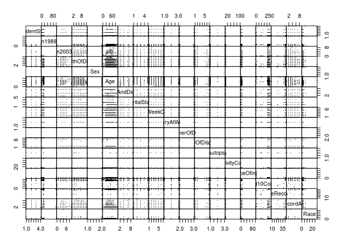

```r
cor.data %>% slice(1:1000)%>% pairs(gap = 0, pch = ".", cex.labels = 1)
```

۲. اثر هر یک از متغیرهای جنسیت، نژاد،آموزش، سن و نحوه تدفین را بر مرگ یا خودکشی ارزیابی کنید.

At first we ran a numebr of chi squared test of independence tests(and a kruskal test for age parameter)to know if various groups of these variables have any difference in Suicide or Homocide between them. The answer is obviously YES, THERE IS DIFFERENCE. for example there is difference between the percentage of Suicide or Homicide between Male and Female. But we Want to plot it so we can see it more clearly

```r
data$MannerOfDeath <- factor(data$MannerOfDeath, labels = c("Suicide", "Homicide"))
cor.data %>% select(MannerOfDeath, Sex) %>%table() %>%  chisq.test()
```

```
##
##  Pearson's Chi-squared test with Yates' continuity correction
##
## data:  .
## X-squared = 24.802, df = 1, p-value = 6.354e-07
```

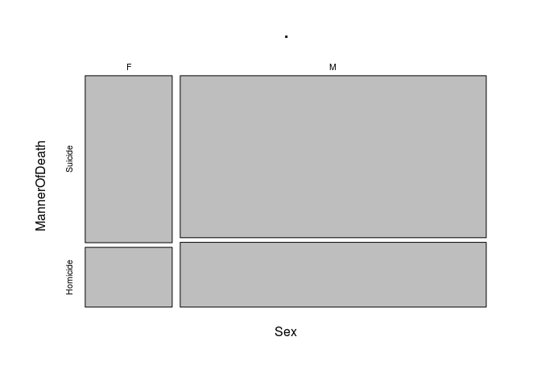

```r
data %>% select(Sex, MannerOfDeath) %>% table() %>% plot()
```

As you can see the Null hypothesis of Independence between Sex and MannerOfDeath is highly rejected. The plot shows that if a woman is killed she more probably killed herself instead of killed by others

```r
cor.data %>% select(MannerOfDeath, Race) %>%table() %>%  chisq.test()
```

```
##
##  Pearson's Chi-squared test
##
## data:  .
## X-squared = 15347, df = 13, p-value < 2.2e-16
```

```r
read_csv("~/University/DataAnalysis/hw_07/data/Race.csv")->race.csv
```

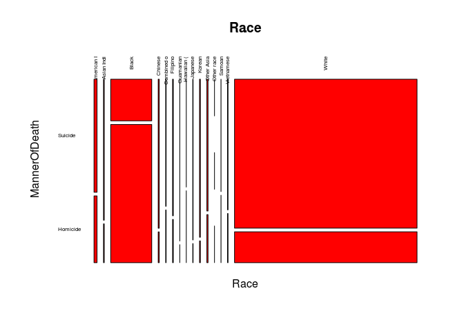

```
## integer(0)
```

```r
data %>% select(Race, MannerOfDeath) %>% full_join(race.csv, by = c("Race"="Code")) %>%
  select(Race = Description, MannerOfDeath) -> race.frame
race.frame$Race <- strtrim(race.frame$Race, 10)
race.frame%>% table()%>% plot(color = "red", las = 2, cex = 0.5)+title("Race")
```

As you can see by the test result’s the Null Hypothesis of Independence between Race and Manner Of Death is highly rejected. That willl be more obvious if you see the plot above.

```r
cor.data %>% select(MannerOfDeath, Education2003Revision) %>%table() %>%  chisq.test()
```

```
##
##  Pearson's Chi-squared test
##
## data:  .
## X-squared = 3567.6, df = 9, p-value < 2.2e-16
```

```r
read_csv("~/University/DataAnalysis/hw_07/data/Education2003Revision.csv")->edu.csv
```

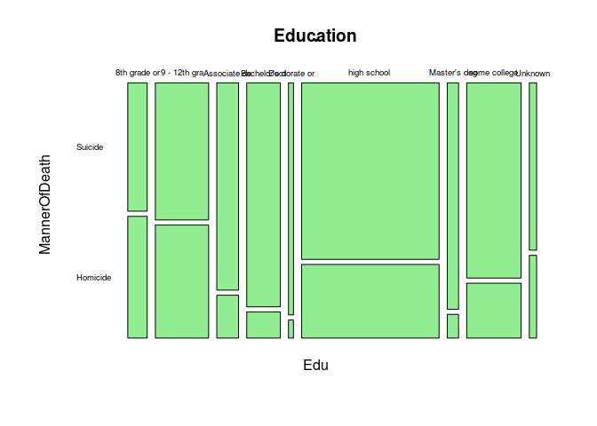

```
## integer(0)
```

```r
data %>% select(Education2003Revision, MannerOfDeath) %>% full_join(edu.csv, by = c("Education2003Revision"="Code")) %>%
  select(Edu = Description, MannerOfDeath) -> edu.frame
edu.frame$Edu <- strtrim(edu.frame$Edu, 12)
edu.frame%>% table()%>% plot(color = "lightgreen", las = 1, cex = 0.6)+title("Education")
```

```r
kruskal.test(data = cor.data, MannerOfDeath~Age)
```

```
##
##  Kruskal-Wallis rank sum test
##
## data:  MannerOfDeath by Age
## Kruskal-Wallis chi-squared = 6887.6, df = 98, p-value < 2.2e-16
```

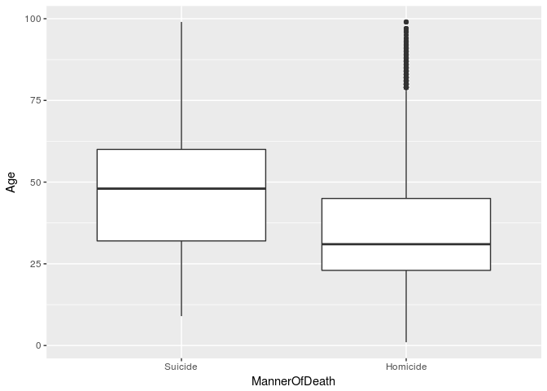

```r
ggplot(data)+geom_boxplot(aes(x = MannerOfDeath, y = Age))
```

By the first Hypothesis test we know there is a difference Because The Null Hypothesis test of no difference between various ages is highly rejected. But A barplot can be more interesting. As we can see the average of age’s between people who suicide is higher. It is logical as you are not going to kill yourself when you are 10 but you can be killed at that age!

```r
cor.data %>% select(MannerOfDeath, MethodOfDisposition) %>% table() %>% chisq.test()
```

```
##
##  Pearson's Chi-squared test
##
## data:  .
## X-squared = 4453.2, df = 6, p-value < 2.2e-16
```

```r
read_csv("~/University/DataAnalysis/hw_07/data/MethodOfDisposition.csv")->dis.csv
```

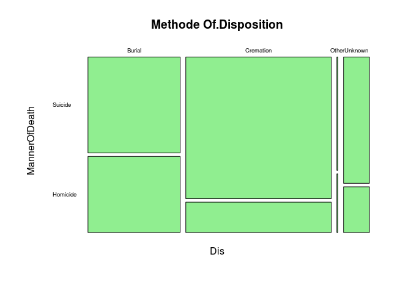

```
## integer(0)
```

```r
data %>% select(MethodOfDisposition, MannerOfDeath) %>% full_join(dis.csv, by = c("MethodOfDisposition"="Code")) %>%
  select(Dis = Description, MannerOfDeath) -> dis.frame
dis.frame$Dis <- strtrim(dis.frame$Dis, 12)
dis.frame%>% table()%>% plot(color = "lightgreen", las = 1, cex = 0.6)+title("Methode Of Disposition")
```

As you can see by the Chi squared test of independence test the Null Hypothesis of Independence between various Methods of Disposition is highly rejected. As you can see in the plot there is a difference actually.

۳. با استفاده از مدل رگرسیون لاجستیک یک مدل به داده ها برازش دهید و سپس آن را نقص یابی کنید.

```r
cor.data %>% mutate(MannerOfDeath = (MannerOfDeath == 3)) -> cor.data
cor.data$MannerOfDeath <- factor(cor.data$MannerOfDeath, labels = c("Suicide", "Homicide"))
glm(formula = MannerOfDeath~.-InjuryAtWork-Race-DayOfWeekOfDeath-MonthOfDeath ,data = cor.data, family = "binomial") -> mylogit
cor.data %>% mutate(pred = fitted(mylogit)) -> cor.data
summary(mylogit)
```

```
##
## Call:
## glm(formula = MannerOfDeath ~ . - InjuryAtWork - Race - DayOfWeekOfDeath -
##     MonthOfDeath, family = "binomial", data = cor.data)
##
## Deviance Residuals:
##     Min       1Q   Median       3Q      Max
## -8.4904  -0.2615  -0.0911   0.0609   6.9354
##
## Coefficients:
##                                  Estimate Std. Error z value Pr(>|z|)
## (Intercept)                    -46.839042   1.463037 -32.015  < 2e-16 ***
## ResidentStatus                  -0.103786   0.031800  -3.264   0.0011 **
## Education1989Revision           -0.007023   0.005438  -1.291   0.1966
## Education2003Revision           -0.174814   0.011974 -14.599  < 2e-16 ***
## Sex                             -0.331039   0.044797  -7.390 1.47e-13 ***
## Age                             -0.019254   0.001114 -17.281  < 2e-16 ***
## PlaceOfDeathAndDecedentsStatus  -0.140791   0.008820 -15.963  < 2e-16 ***
## MaritalStatus                    0.146893   0.020254   7.253 4.09e-13 ***
## MethodOfDisposition             -0.112845   0.014213  -7.939 2.03e-15 ***
## Autopsy                          1.403218   0.042934  32.683  < 2e-16 ***
## ActivityCode                     0.286211   0.004861  58.881  < 2e-16 ***
## PlaceOfInjury                    0.170040   0.002606  65.249  < 2e-16 ***
## Icd10Code                        0.234567   0.003107  75.488  < 2e-16 ***
## CauseRecode39                   -0.303199   0.047106  -6.436 1.22e-10 ***
## NumberOfRecordAxisConditions     0.203146   0.015370  13.217  < 2e-16 ***
## ---
## Signif. codes:  0 '***' 0.001 '**' 0.01 '*' 0.05 '.' 0.1 ' ' 1
##
## (Dispersion parameter for binomial family taken to be 1)
##
##     Null deviance: 71169  on 59949  degrees of freedom
## Residual deviance: 18680  on 59935  degrees of freedom
## AIC: 18710
##
## Number of Fisher Scoring iterations: 9
```

As we can see our model AIC is very good and our model’s parameters are good. We just removed the parameters which do not seem to be helpful in order to debug the model.

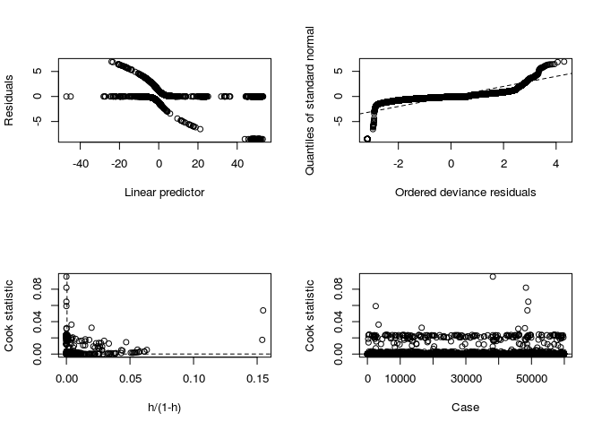

```r
glm.diag.plots(mylogit)
```

As you can see the bottoms we can know there are few outliers here and the Normality plot is good somehow but not that good which is a problem.

۴. با استفاده از سه نمودار خروجی مدل را نسبت به داده واقعی ارزیابی کنید.

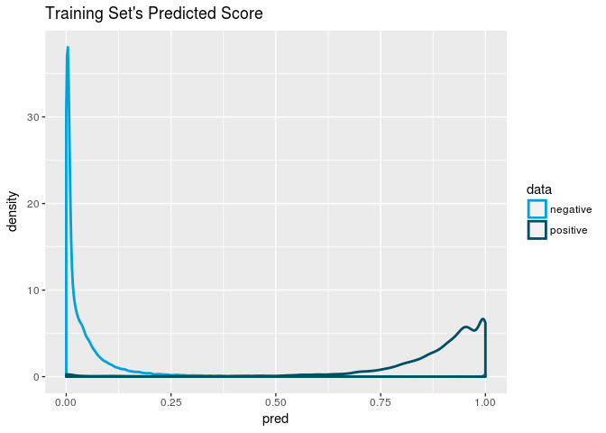

```r
#plot 1
ggplot(cor.data, aes( pred, color = MannerOfDeath))+geom_density( size = 1 ) +
  ggtitle( "Training Set's Predicted Score" ) +
  scale_color_economist( name = "data", labels = c( "negative", "positive" ) )
```

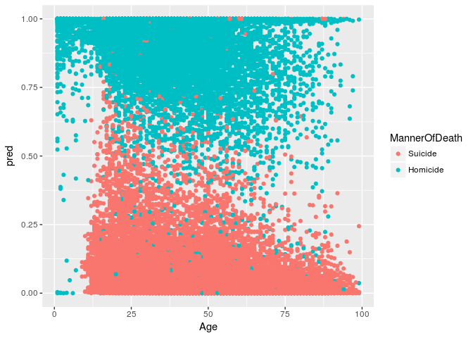

```r
#plot 2
cor.data %>% ggplot(aes(x = Age, y = pred, color = MannerOfDeath)) + geom_point()
```

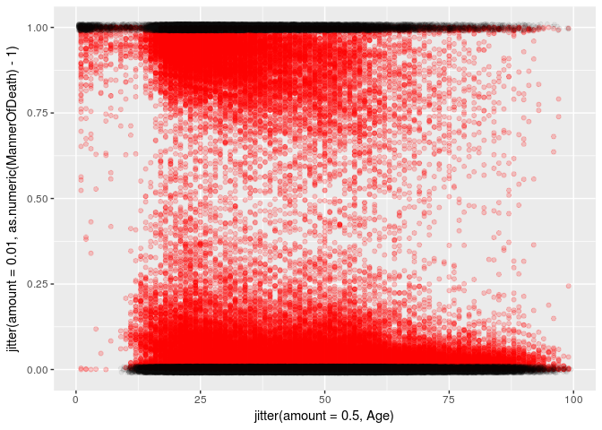

```r
#plot3
cor.data %>%  ggplot(aes(x = jitter(amount= 0.5,Age), y = jitter(amount = 0.01,as.numeric(MannerOfDeath)-1)))+
  geom_point(aes(x = Age, y = pred), color = 'red', alpha = 0.2) + geom_point(alpha = 0.05)
```

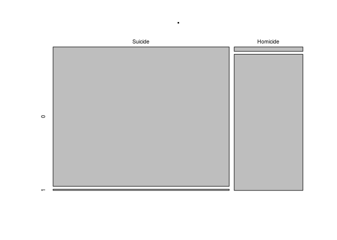

```r
#plot4
table(cor.data$MannerOfDeath,ifelse(cor.data$pred>0.5,1,0)) %>% plot()
```

۵. ابتدا ۲۰ درصد داده را به صورت تصادفی به عنوان تست در نظر بگیرید. مدل را با استفاده از ۸۰ درصد باقی مانده برازش دهید. با استفاده از پارامتر قطع ۰.۵ نتایج را برای داده تست پیش بینی کنید. سپس کمیت های زیر را محاسبه کنید.

- P: positive samples
- N: negative samples
- TP: true positive TP (eqv. with hit)
- TN: true negative (eqv. with correct rejection)
- FP: false positive (eqv. with false alarm, Type I error)
- FN: false negative (eqv. with miss, Type II error)
- Accuracy (ACC) ACC = (TP+TN)/(P+T)
- False positive rate (FPR): 1- TN/N
- True positive rate (TPR): TP/P

مشابه آنچه در کلاس گفته شد نمایشی از چهار کمیت TN, TP,FP,FN به همراه داده ها رسم نمایید.

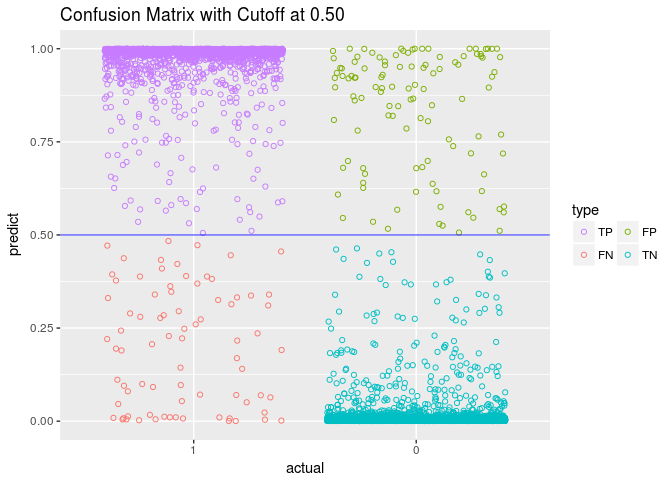

```r
cor.data <- cor.data[sample(nrow(cor.data)),]
trainindex <- sample(1:nrow(cor.data), 0.8*nrow(cor.data), replace = FALSE)
validindex <- 1:nrow(cor.data) %>% setdiff(trainindex)
train <- cor.data[trainindex,]
valid <- cor.data[validindex,]
glm(formula = MannerOfDeath~.-InjuryAtWork-Race-DayOfWeekOfDeath-MonthOfDeath ,data = train, family = "binomial") -> molog
valid$pred <- predict(object = molog, valid, type = "response")

P <- sum(valid$pred > 0.5)
N <- sum(valid$pred < 0.5)
TP <- sum(valid$pred > 0.5 & as.logical(valid$MannerOfDeath == "Homicide"))
FP <- P-TP
TN <- sum(valid$pred < 0.5 & as.logical(valid$MannerOfDeath == "Suicide"))
FN <- N - TN
ACC <- (TP+TN)/(P+N)
FPR <- 1- TN/N
TPR<- TP/P

valid %>% mutate(MannerOfDeath = as.integer(MannerOfDeath == "Homicide")) -> valid.integer
cm_info <- ConfusionMatrixInfo(data = valid.integer, predict = "pred",actual = "MannerOfDeath", cutoff = .5)
cm_info$plot
```

۶. نمودار صحت مدل (accuracy) را بر حسب مقادیر مختلف قطع برای داده تست رسم نمایید. کدام پارامتر قطع بالاترین صحت را در پیش بینی داراست؟

```r
acc_comp <- function(data, mahak){
  P <- sum(data$pred > mahak)
  N <- sum(data$pred < mahak)
  TP <- sum(data$pred > mahak & as.logical(data$MannerOfDeath == "Homicide"))
  FP <- P-TP
  TN <- sum(data$pred < mahak & as.logical(data$MannerOfDeath == "Suicide"))
  FN <- N - TN
  ACC <- (TP+TN)/(P+N)
  return(ACC)
}
xs <- seq(0, to = 1, by = 0.001)
sapply(xs, function(x){
  acc_comp(valid, x)
}) -> accs_valid
sapply(xs, function(x){
  acc_comp(train, x)
}) -> accs_train
m <- max(accs_valid)
mi = which(accs_valid == m)[1]
print(xs[mi])
```

```
## [1] 0.561
```

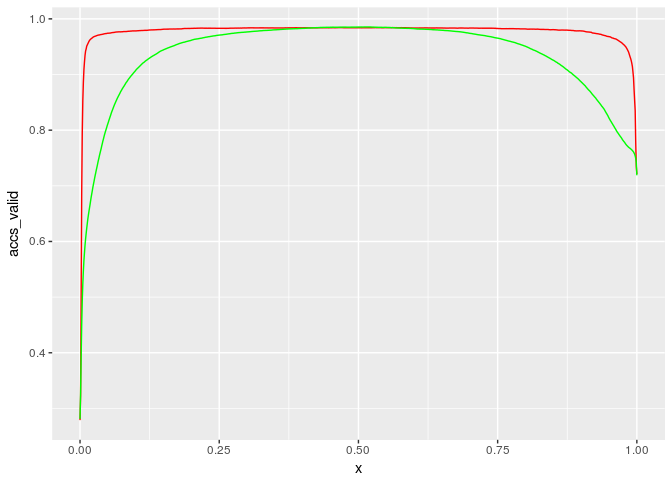

```r
df <- data.frame(x = xs, valids = accs_valid, trains = accs_train)
ggplot(df)+geom_line(aes(x = x, y = accs_valid), color = "red")+geom_line(aes(x = x, y = accs_train), color = "green")
```

۷. نمودار ROC را برای داده های قسمت قبل رسم نمایید. همچنین نقطه مربوط به بهترین پارامتر قطع را مشخص نمایید.

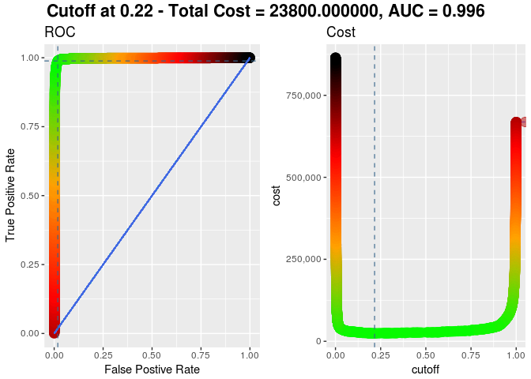

```r
cost_fp = 100.0;cost_fn = 200.0
roc_info = ROCInfo( data = cm_info$data, predict = "predict",
                    actual = "actual", cost.fp = cost_fp, cost.fn = cost_fn )
grid.draw(roc_info$plot)
```

۸. با قرار دادن کمیت nfolds = 5 و با استفاده از H20 مدل مساله را بسازید و نتیجه حاصل را ارزیابی کنید.

```r
library(h2o)
h2o.init()
```

```
##
## H2O is not running yet, starting it now...
##
## Note:  In case of errors look at the following log files:
##     /tmp/RtmpCinpa0/h2o_miladink_started_from_r.out
##     /tmp/RtmpCinpa0/h2o_miladink_started_from_r.err
##
##
## Starting H2O JVM and connecting: .. Connection successful!
##
## R is connected to the H2O cluster:
##     H2O cluster uptime:         3 seconds 955 milliseconds
##     H2O cluster timezone:       Asia/Tehran
##     H2O data parsing timezone:  UTC
##     H2O cluster version:        3.19.0.4275
##     H2O cluster version age:    1 day
##     H2O cluster name:           H2O_started_from_R_miladink_vgc847
##     H2O cluster total nodes:    1
##     H2O cluster total memory:   1.27 GB
##     H2O cluster total cores:    8
##     H2O cluster allowed cores:  8
##     H2O cluster healthy:        TRUE
##     H2O Connection ip:          localhost
##     H2O Connection port:        54321
##     H2O Connection proxy:       NA
##     H2O Internal Security:      FALSE
##     H2O API Extensions:         XGBoost, Algos, AutoML, Core V3, Core V4
##     R Version:                  R version 3.4.4 (2018-03-15)
```

```r
hcor.data <- as.h2o(cor.data)
chglm = h2o.glm(y = "MannerOfDeath", x= cor.data %>% colnames() %>% setdiff("MannerOfDeath"),
                training_frame =  hcor.data , family="binomial",nfolds = 5)
summary(chglm)
```

```
## Model Details:
## ==============
##
## H2OBinomialModel: glm
## Model Key:  GLM_model_R_1524864829155_1
## GLM Model: summary
##     family  link                                regularization
## 1 binomial logit Elastic Net (alpha = 0.5, lambda = 8.575E-4 )
##   number_of_predictors_total number_of_active_predictors
## 1                         19                          15
##   number_of_iterations training_frame
## 1                    6       cor.data
##
## H2OBinomialMetrics: glm
## ** Reported on training data. **
##
## MSE:  0.01157967
## RMSE:  0.1076089
## LogLoss:  0.05005955
## Mean Per-Class Error:  0.01855276
## AUC:  0.9968765
## Gini:  0.993753
## R^2:  0.9426425
## Residual Deviance:  6002.14
## AIC:  6034.14
##
## Confusion Matrix (vertical: actual; across: predicted) for F1-optimal threshold:
##          Homicide Suicide    Error        Rate
## Homicide    16363     462 0.027459  =462/16825
## Suicide       416   42709 0.009646  =416/43125
## Totals      16779   43171 0.014646  =878/59950
##
## Maximum Metrics: Maximum metrics at their respective thresholds
##                         metric threshold    value idx
## 1                       max f1  0.512526 0.989826 199
## 2                       max f2  0.235569 0.991547 256
## 3                 max f0point5  0.841847 0.992472 120
## 4                 max accuracy  0.518419 0.985354 198
## 5                max precision  0.998303 1.000000   0
## 6                   max recall  0.000160 1.000000 399
```

[output cut: 98 more lines]

```
## 5    NumberOfRecordAxisConditions     0.184565  POS
## 6           Education2003Revision     0.138477  NEG
## 7                   PlaceOfInjury     0.112836  NEG
## 8             MethodOfDisposition     0.096465  NEG
## 9                         Autopsy     0.043049  POS
## 10                  MaritalStatus     0.039721  POS
## 11                            Sex     0.025648  NEG
## 12                   InjuryAtWork     0.017183  NEG
## 13                  CauseRecode39     0.010635  POS
## 14                           Race     0.010434  NEG
## 15                 ResidentStatus     0.001345  NEG
## 16          Education1989Revision     0.000000  POS
## 17                   MonthOfDeath     0.000000  POS
## 18 PlaceOfDeathAndDecedentsStatus     0.000000  POS
## 19               DayOfWeekOfDeath     0.000000  POS
```

۹. آیا ما میتوانیم سرویسی به قضات ارایه کنیم تا با استفاده از اطلاعات مرگ بتوانند موارد مشکوک به قتل را از خودکشی تفکیک دهند؟

Our Accuracy is $0.985$ which is Good Enough to help the Judge’s. We cannot say we are perfect and so we can just say to the judge which event is more likely to be a Homicide so it should be explored mpore deeply than the others.